# PF-0953 Programación geoespacial en R Proyecto 01: R - Visualización de datos vectoriales

Kevin Chavarría ESquivel, Dilena Cruz Fernandez, Alvaro Vásquez Anchía

2020-10-07

## Desarrollo

En los siguientes ejercicios se utiliza el data frame `world`, contenido en el paquete [spData](https://cran.r-project.org/web/packages/spData/). Escriba el código en R necesario para realizar cada ejercicio.

### Carga de paquetes

```r
# Paquete para generación de documentos (ej. HTML)
library(knitr)
# Paquete para formateo de tablas
library(kableExtra)
# Paquete de graficación
library(ggplot2)
# Paquete de manejo de datos geoespaciales vectoriales
library(sf)
# Paquete con conjuntos de datos geoespaciales
library(spData)
# paquete de manejo de datos
library(dplyr)
#modifica escalas o notaciones
library(scales)
library(gridExtra)
```

Realice los siguientes ejercicios de graficación y manejo de datos vectoriales en R (el valor porcentual de cada uno se muestra entre paréntesis).

### Ejercicio 1 (5%)

Mediante la función `names()`, observe las columnas que componen el data frame `world`.

```r
names(world)
```

```
##  [1] "iso_a2"    "name_long" "continent" "region_un" "subregion" "type"
##  [7] "area_km2"  "pop"       "lifeExp"   "gdpPercap" "geom"
```

### Ejercicio 2 (5%)

Mediante la función [kable()](https://www.rdocumentation.org/packages/knitr/versions/1.30/topics/kable) del paquete [knitr](https://cran.r-project.org/web/packages/knitr/), despliegue en una tabla las diez primeras observaciones (i.e. filas, registros) y las cinco primeras variables (i.e. columnas) del data frame `world`.

```r
kable(
  world[1:10, 1:5, drop = TRUE],
  caption="Datos demográficos de los países del mundo"
)
```

Datos demográficos de los países del mundo

| iso_a2 | name_long | continent | region_un | subregion |
| --- | --- | --- | --- | --- |
| FJ | Fiji | Oceania | Oceania | Melanesia |
| TZ | Tanzania | Africa | Africa | Eastern Africa |
| EH | Western Sahara | Africa | Africa | Northern Africa |
| CA | Canada | North America | Americas | Northern America |
| US | United States | North America | Americas | Northern America |
| KZ | Kazakhstan | Asia | Asia | Central Asia |
| UZ | Uzbekistan | Asia | Asia | Central Asia |
| PG | Papua New Guinea | Oceania | Oceania | Melanesia |
| ID | Indonesia | Asia | Asia | South-Eastern Asia |
| AR | Argentina | South America | Americas | South America |

### Ejercicio 3 (5%)

Mediante la función `kable()`, despliegue en una tabla las diez primeras observaciones y las variables correspondientes a nombre del país, continente, población, esperanza de vida y renta per cápita del data frame `world`. Despliegue los nombres de las columnas en español y un título para la tabla.

```r
kable(
  world[1:10, c("name_long","continent","pop","lifeExp","gdpPercap"), drop = TRUE],
  col.names=c("País","Continente","Población","Esperanza de vida","Renta per cápita"),
  caption="Datos demográficos de los países del mundo"
)
```

Datos demográficos de los países del mundo

| País | Continente | Población | Esperanza de vida | Renta per cápita |
| --- | --- | --- | --- | --- |
| Fiji | Oceania | 885806 | 69.96000 | 8222.254 |
| Tanzania | Africa | 52234869 | 64.16300 | 2402.099 |
| Western Sahara | Africa | NA | NA | NA |
| Canada | North America | 35535348 | 81.95305 | 43079.143 |
| United States | North America | 318622525 | 78.84146 | 51921.985 |
| Kazakhstan | Asia | 17288285 | 71.62000 | 23587.338 |
| Uzbekistan | Asia | 30757700 | 71.03900 | 5370.866 |
| Papua New Guinea | Oceania | 7755785 | 65.23000 | 3709.082 |
| Indonesia | Asia | 255131116 | 68.85600 | 10003.089 |
| Argentina | South America | 42981515 | 76.25200 | 18797.548 |

### Ejercicio 4 (5%)

A partir de `world`, genere un nuevo data frame ordenado por nombre de país. Despliegue los datos en una tabla y utilice las funciones [kable_styling()](https://www.rdocumentation.org/packages/kableExtra/versions/1.2.1/topics/kable_styling) y [scroll_box()](https://www.rdocumentation.org/packages/kableExtra/versions/1.2.1/topics/scroll_box) del paquete [kableExtra](https://cran.r-project.org/web/packages/kableExtra/), para desplegar todas las observaciones, con las mismas variables del ejercicio anterior, y agregar una barra de desplazamiento.

```r
# Se extraen las observaciones ordenadas por orden alfabético de país
world.orden <- order(world$name_long)
# Se genera un nuevo data frame ordenado
world.ordenadoxpais <- world[world.orden,]
# Se formatea la tabla con el nuevo data frame
kable(
  world.ordenadoxpais[, c("name_long","continent","pop","lifeExp","gdpPercap"), drop = TRUE],
  col.names=c("País","Continente","Población","Esperanza de vida","Renta per cápita"),
  caption="Datos demográficos de los países del mundo"
) %>%
  kable_styling() %>%
  scroll_box(
    width = "800px",
    height = "500px",
    fixed_thead = TRUE
  )
```

Datos demográficos de los países del mundo

| País | Continente | Población | Esperanza de vida | Renta per cápita |
| --- | --- | --- | --- | --- |
| Afghanistan | Asia | 32758020 | 62.89500 | 1838.9602 |
| Albania | Europe | 2889104 | 77.96300 | 10701.1208 |
| Algeria | Africa | 39113313 | 75.64100 | 13483.3379 |
| Angola | Africa | 26920466 | 60.85800 | 6257.1529 |
| Antarctica | Antarctica | NA | NA | NA |
| Argentina | South America | 42981515 | 76.25200 | 18797.5479 |
| Armenia | Asia | 2906220 | 74.25500 | 7971.1179 |
| Australia | Oceania | 23504138 | 82.30000 | 43547.1975 |
| Austria | Europe | 8546356 | 81.49024 | 44320.5020 |
| Azerbaijan | Asia | 9535079 | 71.80000 | 16715.1055 |
| Bahamas | North America | 382169 | 75.37900 | 28456.8165 |
| Bangladesh | Asia | 159405279 | 71.80300 | 2973.0416 |
| Belarus | Europe | 9474511 | 72.97073 | 17944.2098 |
| Belgium | Europe | 11209057 | 81.28780 | 41360.3956 |
| Belize | North America | 351694 | 70.02700 | 7999.5737 |
| Benin | Africa | 10286712 | 60.37300 | 2001.0773 |
| Bhutan | Asia | 776448 | 69.43000 | 7366.4241 |
| Bolivia | South America | 10562159 | 68.35700 | 6324.8273 |
| Bosnia and Herzegovina | Europe | 3566002 | 76.56100 | 10516.7864 |
| Botswana | Africa | 2168573 | 64.78000 | 15914.6702 |
| Brazil | South America | 204213133 | 75.04200 | 15374.2615 |
| Brunei Darussalam | Asia | 411704 | 76.91700 | 76089.2866 |
| Bulgaria | Europe | 7223938 | 74.46585 | 16302.3206 |
| Burkina Faso | Africa | 17585977 | 59.45700 | 1582.3337 |
| Burundi | Africa | 9891790 | 56.68800 | 803.1728 |
| Cambodia | Asia | 15270790 | 68.25100 | 3124.3193 |
| Cameroon | Africa | 22239904 | 57.11100 | 3196.3615 |
| Canada | North America | 35535348 | 81.95305 | 43079.1425 |
| Central African Republic | Africa | 4515392 | 50.62100 | 597.1352 |
| Chad | Africa | 13569438 | 52.20400 | 2076.6500 |

[output cut: 147 more lines]

Note el uso del [operador `%>%`](https://www.datacamp.com/community/tutorials/pipe-r-tutorial), llamado *pipe* (tubo, cañería), para pasar datos entre funciones.

### Ejercicio 5 (5%)

Filtre el data frame `world` para extraer en otro data frame las observaciones correspondientes a los siete países de Centroamérica. Mantenga las mismas columnas de los ejercicios anteriores y despliegue los datos en una tabla.

```r
# Se extraen las observaciones correspondientes a los países de Centroamérica
centro_america = world[world$name_long == "Belize" |
                         world$name_long == "Guatemala" |
                         world$name_long == "Honduras" |
                         world$name_long == "El Salvador" |
                         world$name_long == "Nicaragua" |
                         world$name_long == "Costa Rica" |
                         world$name_long == "Panama"
                       , ]
# Se formatea la tabla con el nuevo data frame
kable(
  centro_america[, c("name_long","continent","pop","lifeExp","gdpPercap"), drop = TRUE],
  col.names=c("País","Continente","Población","Esperanza de vida","Renta per cápita"),
  caption="Datos demográficos de los países de Centroamérica"
) %>%
  kable_styling()
```

Datos demográficos de los países de Centroamérica

| País | Continente | Población | Esperanza de vida | Renta per cápita |
| --- | --- | --- | --- | --- |
| Panama | North America | 3903986 | 77.610 | 20017.994 |
| Costa Rica | North America | 4757575 | 79.440 | 14372.401 |
| Nicaragua | North America | 6013997 | 74.884 | 4784.830 |
| Honduras | North America | 8809216 | 73.181 | 4231.325 |
| El Salvador | North America | 6281189 | 73.015 | 6890.723 |
| Guatemala | North America | 15923559 | 72.869 | 7147.429 |
| Belize | North America | 351694 | 70.027 | 7999.574 |

### Ejercicio 6 (15%)

Con la función `ggplot()` del paquete [ggplot2](https://ggplot2.tidyverse.org/), genere un gráfico de barras que muestre la esperanza de vida de los países del continente asiático en los que esa esperanza de vida sea de al menos 80 años. El gráfico debe tener un título, los nombres (o códigos) de los países bajo cada barra, los valores sobre las barras y etiquetas para los ejes x e y.

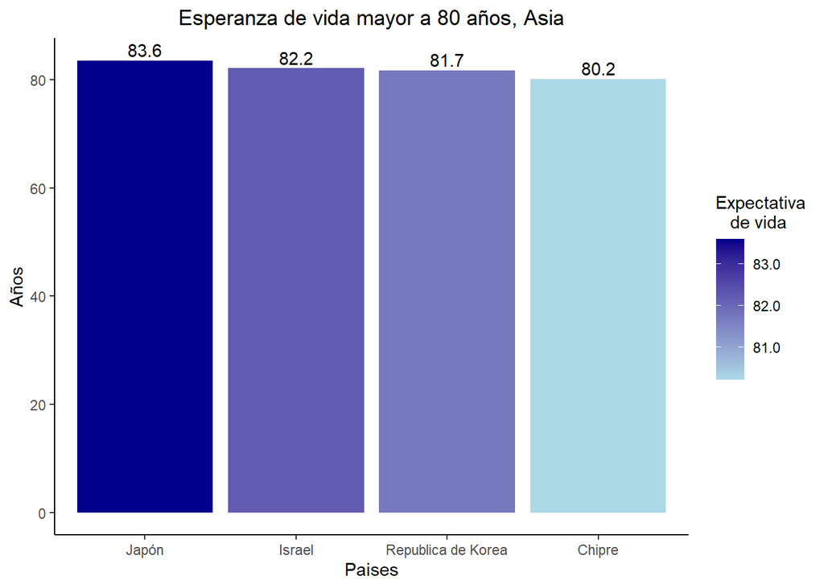

```r
asia <- world[world$continent == "Asia",] %>%
  filter(lifeExp >= 80)

ggplot(asia, aes(x=reorder(name_long, -lifeExp), y= lifeExp))+
  geom_col(aes(fill= round(lifeExp, 1)), position = "dodge")+
  geom_text(aes(label= round(lifeExp, 1), vjust=-0.3))+
  scale_x_discrete(
    breaks = c("Japan", "Israel", "Republic of Korea", "Cyprus"),
    label = c("Japón", "Israel", "Republica de Korea", "Chipre"))+
  scale_fill_gradient(low = "lightblue", high = "darkblue", name = "Expectativa\n   de vida", labels = comma)+
  theme_classic()+ xlab("Paises")+ ylab("Años")+
  ggtitle("Esperanza de vida mayor a 80 años, Asia")+
  theme(plot.title = element_text(hjust = 0.5))
```

### Ejercicio 7 (20%)

Con la función `plot()` del paquete [sf](https://cran.r-project.org/web/packages/sf/index.html), genere un [mapa de coropletas](https://en.wikipedia.org/wiki/Choropleth_map) con colores que reflejen la esperanza de vida de los países del continente llamado Oceanía. El mapa debe llevar un título.

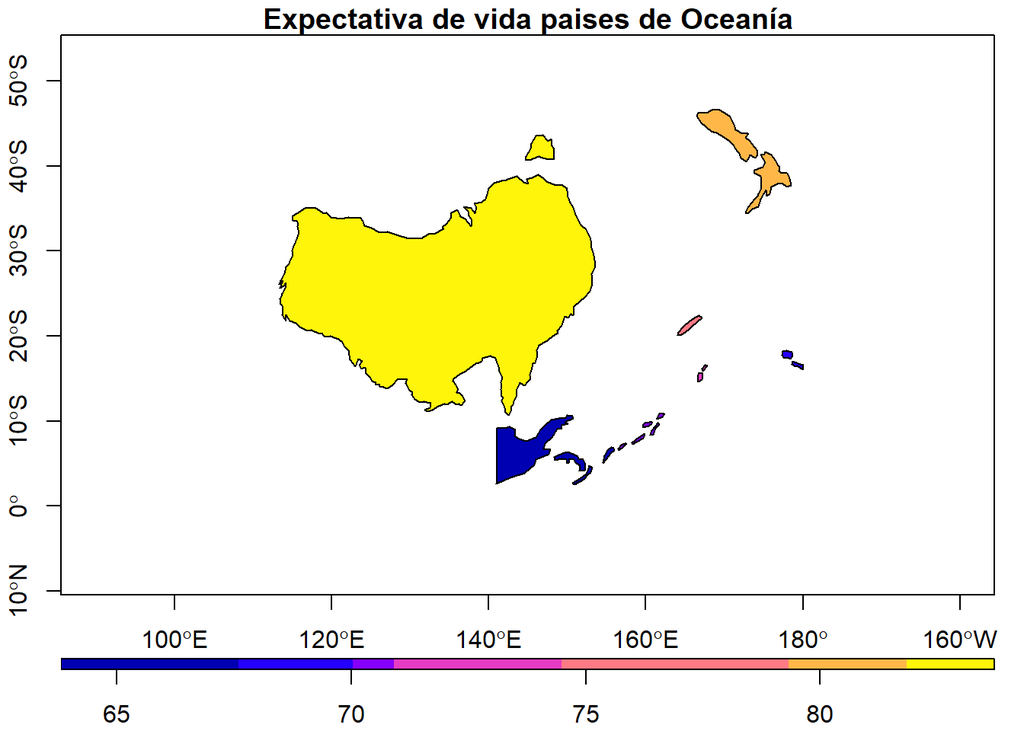

```r
oceania <- world[world$continent == "Oceania",]

plot(oceania["lifeExp"], main="Expectativa de vida paises de Oceanía", xlim = c(90,200), ylim = c(-15,-30),
     axes=TRUE, key.width = lcm(1.3), key.length = 1.0)
```

### Ejercicio 8 (20%)

Extraiga en un nuevo data frame los países de Centroamérica con esperanza de vida mayor o igual a 74 años y genere el mapa de coropletas, con su título correspondiente.

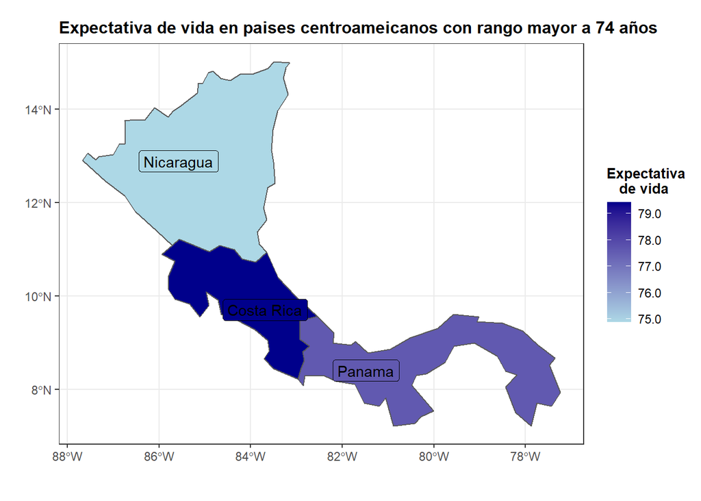

```r
centroamerica <- world[world$subregion == "Central America",] %>%
  filter(name_long != "Mexico",
         lifeExp >= 74)

ggplot(centroamerica, aes(fill=lifeExp))+
  geom_sf()+
  geom_sf_label(aes(label=name_long))+
  scale_fill_gradient(low = "lightblue", high = "darkblue", name = "Expectativa\n   de vida", labels = comma)+
  ggtitle("Expectativa de vida en paises centroameicanos con rango mayor a 74 años")+
  xlab("")+ylab("")+
  theme_bw()+
  theme(title =element_text(size=10, face='bold'))
```

### Ejercicio 9 (20%)

Extraiga en un nuevo data frame los países de América del Sur con área de al menos 2.5 millones de km2 o población de al menos 40 millones de personas y genere un mapa de coropletas para cada variable (i.e. área y población), con sus títulos correspondientes.

```r
#entendimos que se referia a dos graficos, uno para cada variable (area y poblacion)
```

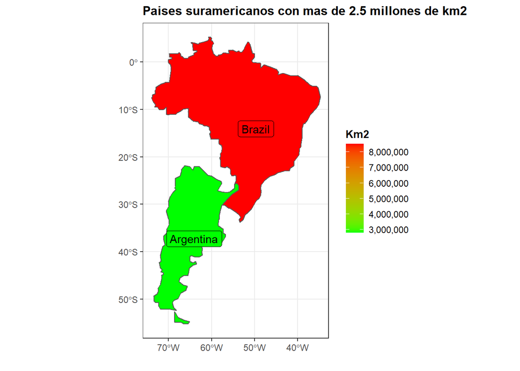

```r
suramerica <- world[world$subregion == "South America",] %>%
  filter(area_km2 >= 2500000)

ggplot(suramerica, aes(fill=area_km2))+
  geom_sf()+
  geom_sf_label(aes(label=name_long))+
  scale_fill_gradient(low = "green", high = "red", name = "Km2", labels = comma)+
  ggtitle("Paises suramericanos con mas de 2.5 millones de km2")+
  xlab("")+ylab("")+
  theme_bw()+
  theme(title =element_text(size=10, face='bold'))
```

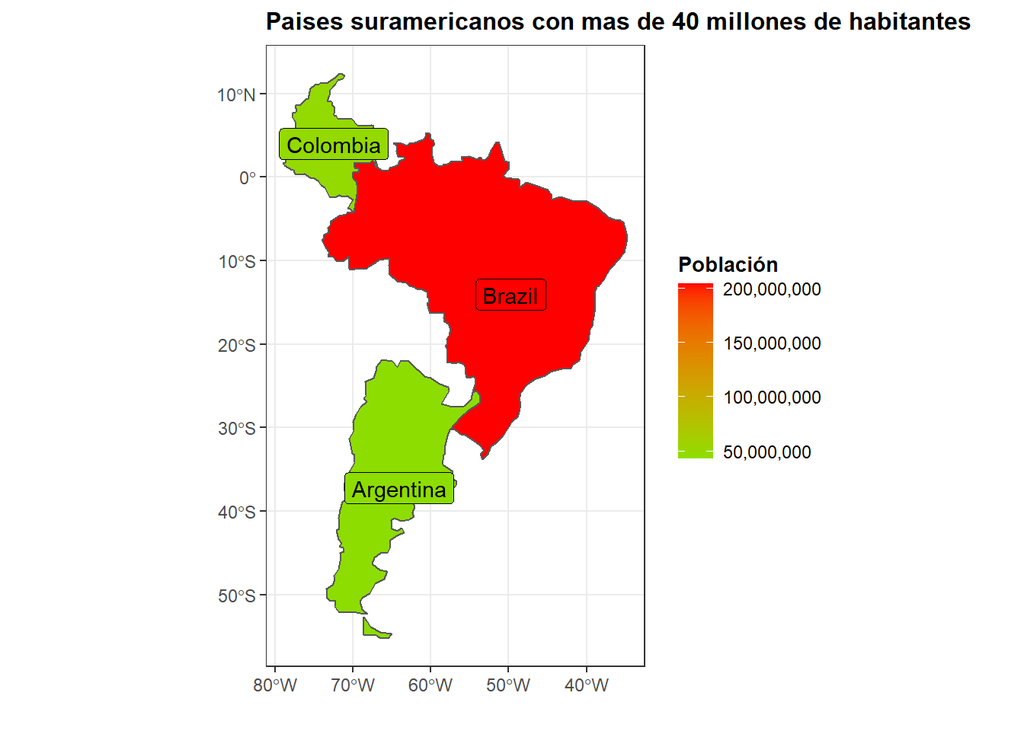

```r
popsuramerica <- world[world$subregion == "South America",] %>%
  filter(pop >= 40000000)

ggplot(popsuramerica, aes(fill=pop))+
  geom_sf()+
  geom_sf_label(aes(label=name_long))+
  scale_fill_gradient2(low = "blue", mid= "green", high = "red", name = "Población", labels = comma)+
  ggtitle("Paises suramericanos con mas de 40 millones de habitantes")+
  xlab("")+ylab("")+
  theme_bw()+
  theme(title =element_text(size=10, face='bold'))
```